# Aesthetic Mapping

Evangeline Reynolds

4/6/2020

# Set-up… Data package and ggplot2 package

```r
library(gapminder)
library(ggplot2)
```

# Data manipulation

```r
gm_2002 <- gapminder[gapminder$year == 2002, ]
gm_2002_eu <- gm_2002[gm_2002$continent == "Europe", ]
continent_count <- data.frame(continent = c("Africa", "Americas", "Asia", "Europe", "Oceania"),
                              count = c(52, 25, 33, 30, 2))
```

## Task 1: First plot (same as Hans Rosling – but a moment in time - 2002)

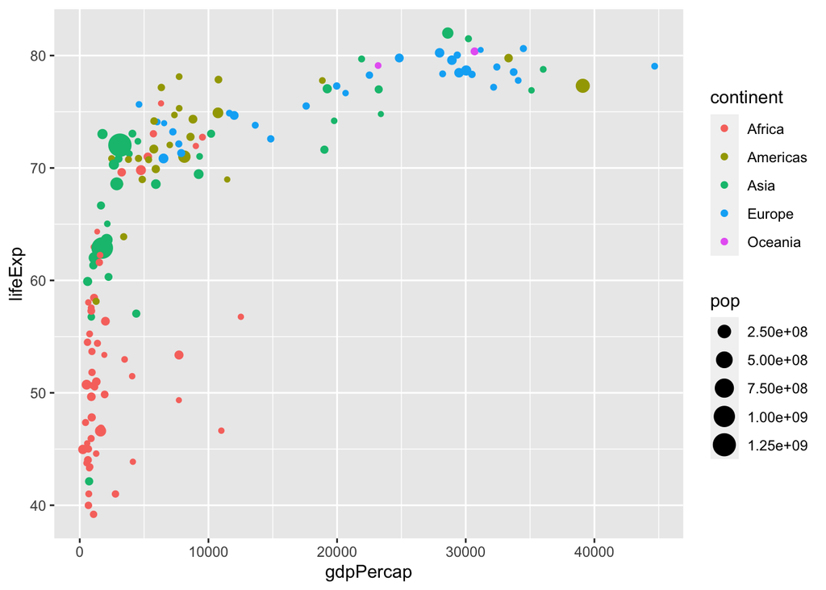

```r
ggplot(data = gm_2002) +
  aes(x = gdpPercap) +
  aes(y = lifeExp) +
  geom_point() +
  aes(size = pop) +
  aes(color = continent)
```

# Task 2:

- Use *shape* instead of *color* to represent continent.

# Task 3:

- Use *shape* and *color* to representing continent.

# Task 4:

- use the aesthetic named *alpha* to represents gdp per cap

What does this aesthetic seem to be?

> Your answer

# Task 5:

# plotting the gm_2002_eu data

create a ggplot where the data is gm_2002_eu (look at the result as you build your plots)

- have *x* represent the variable gdp per capita
- have *y* represent the variable life expectancy
- have *color* represent the variable population
- use a **point** to take on these aesthetics (i.e add a geom_point() statement)
- *also* use a **rug** geometry to take on these aesthetics (i.e. add a geom_rug() statement)
- have *label* represent the variable continent, then switch to country
- use **text** *also* to take on these aesthetics (i.e. add a geom_text() statement – will look a bit messy - don’t worry about this).

Answer the question: What is the *default color scale* for continuous variables?

> your answer here

Does it make more sense for the variable continent or country to be represented by the label aesthetic?

> your answer here

# Task 6:

# The continent_count data

In a new code chunk create a plot:

- where the data is continent_count (this much is set up for you)
- where *x* represent the variable continent
- where *y* represent the variable count
- where the geom taking on the x and y position is **point**

```r
ggplot(data = continent_count)
```

# Task 7:

Now, using the code above, change geom_point() to geom_col(). *In addition* to *x* representing continent and *y* representing count:

- have *color* represent continent
- have *linetype* represent continent
- have *fill* represent continent
- have *alpha* represent count

**Execute the code as you build to see the changes you are triggering.**

Based on your experience above, how is the aesthetic, *fill*, different from the aesthetic *color*?

> your answer here

# Task 8:

# geom_tile()

The next plot you’ll create uses the **tile** geom, geom_tile().

Use the data, gm_americas, that is created below. Then build the plot (it is started for you).

- have *x* position represent year
- have *y* position represent country
- have the geometric shape **tiles** take in the x and y aesthetics (i.e. add a geom_tile() statement)
- have *fill* represent life expectancy (lifeExp)

```r
gm_americas <- gapminder[gapminder$continent == "Americas",]

ggplot(data = gm_americas)
```

# Task 9:

# A scatter plot with cars

Examine the data “cars” that is available from “base” R. You can search cars in the help, if you need a reminder

Build a scatterplot with this data in ggplot2 (i.e. declare the data, declare desired aesthetic representation, and use geom_point() ).

```r
ggplot(data = cars)
```

# Task 10:

# A scatterplot with pressure

Examine the data “pressure” that is available from “base” R. You can search pressure in the help, if you need a reminder.

Build a scatterplot with this data in ggplot2 (i.e. declare the data, declare aesthetic representation, and use geom_point() ).

```r
ggplot(data = pressure)
```

# Task 11:

# geom_rect()

Execute the code below, then just answer the questions.

The geom_rect() is a rectangle defined by xmin, xmax, ymin, and ymax. Here were seeing a few new things. First we can make adjustments on the fly to variables. It might be best to show gdpPercap **in thousands**. We can do that *on the fly*, by dividing by 1000. Same with population — writing all the zeros out is not a great choice, we can report in millions — so we divide the variable through by 1000000.

Can you do arithmetic operations with variables on the fly?

> yes or no?

We can also create something like a variable on the fly. Where we see xmin set to zero, *this is like having a variable (a column in the data), that is filled from top to bottom with zeros*. Same with ymin.

We see xmin set to zero. What is this like? You can retype the explanation imediately above, try to internalize of course.

> your answer here…

We also see facet_wrap(~country) being used. Describe the behavior of facet_wrap(~country) — (i.e. What does it do?)

> your answer

What does the area of the rectangle capture? Hint, the width is gdp per cap, and the height is population. The area is multiplying these two giving you …

> your idea here…

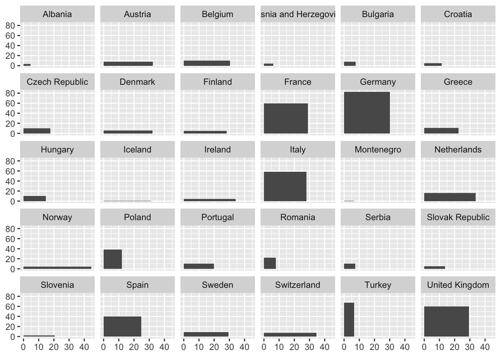

```r
options(scipen = 10)  # this tells r to not turn on scientific notation too soon

# this is a comment - if you want to write comments
# use the hashtag at the beginning of the line
ggplot(data = gm_2002_eu) +
  aes(xmax = gdpPercap/1000) +
  aes(ymax = pop/1000000) +
  aes(xmin = 0) +
  aes(ymin = 0) +
  geom_rect() +
  facet_wrap(~country)
```

# Task 12:

Execute the code below.

What aes() statements does the point use?

What aes() statements does the segement use?

You can also search geom_point and geom_segment in Rstudio help to answer these questions. Scroll down in the “documentation” to the section “Aesthetics”.

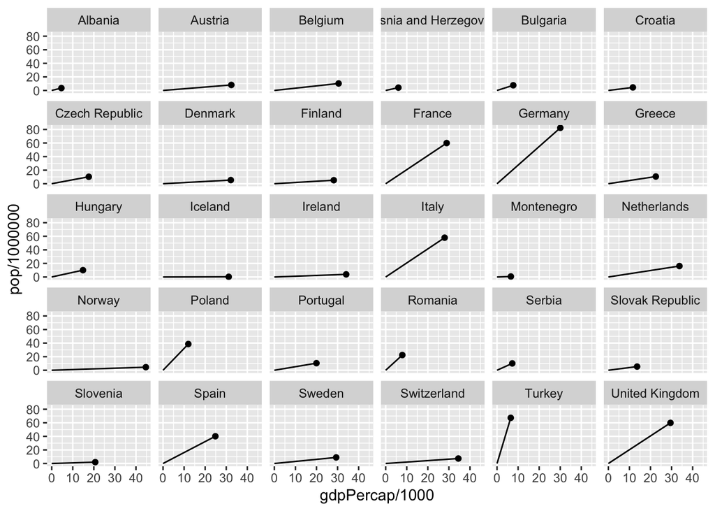

```r
options(scipen = 10)
ggplot(data = gm_2002_eu) +
  aes(x = gdpPercap/1000) +
  aes(y = pop/1000000) +
  aes(xend = 0) +
  aes(yend = 0) +
  geom_segment() +
  geom_point() +
  facet_wrap(~country)
```

# Task 13: Deconstructing a plot.

Examine code below, and execute.

What is the name of the object which contains the dataset for the plot?

> your answer

What variable is represented by the x position?

> your answer

What variable is represented by the y position?

> your answer

What is the geometric shape that is taking on the aesthetic representations?

> your answer

Is there a probelm with this visual representation? If yes, describe that problem…

> your answer

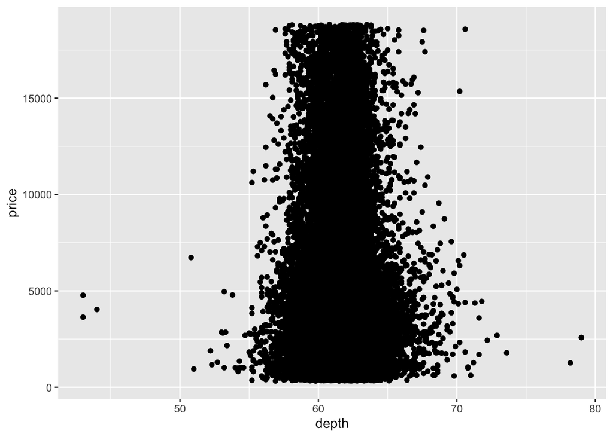

```r
ggplot(data = diamonds) +
  aes(x = depth) +
  aes(y = price) +
  geom_point()
```

# Task 14: Write the concise “grammar of graphics” definition of a data visualization/statistical graphic (choose either the colloquial or academic).

> A data visualization is …

or

> A statistical graphic is …

Note the parallel with construction of ggplots:

declare data +

declare aesthetic representations +

declare geometry that will take on aesthetics.